# Exploratory Data Analysis

1. Import libraries as needed
2. Expand maximum range of rows
3. Import athleisure dataset
4. Find total volume per engine
5. Find average search volume each month across all engines
6. Find average volume for each keyword on each search engine
7. Find average volume for each keyword across all search engines
8. Find total volume for each keyword across all search engines
9. Wordclouds for athleisure search volume
10. PDF and CDF for an athleisure keyword having a total search volume

### 1. Import libraries as needed

```python
import matplotlib.pyplot as plt
import matplotlib.ticker as ticker
%matplotlib inline
import seaborn as sns
import numpy as np
import pandas as pd
import requests
import json
import sklearn
from scipy import stats
from scipy.stats import norm
from sklearn.utils import resample
import pickle
import statsmodels.api as sm
from statsmodels.formula.api import ols
import scipy.stats as stats
from wordcloud import WordCloud
import random
```

### 2. Expand maximum range of rows

May be a good idea to expand the maximum range of rows to view in your Pandas dataframes.  
Use **pd.set_option()**

```python
pd.set_option('display.max_rows', 3000)
pd.set_option('display.max_columns', 3000)
pd.set_option('display.width', 3000)
```

### 3. Import athleisure dataset

```python
df = pd.read_csv("/Users/alexandercheng/Desktop/code/projects/athleisure-ads-strategy/athleisure.csv")
df.head()
```

|  | Unnamed: 0 | keyword | volume | year | month | engine | total_volume_for_last_12_months | avg_volume_for_last_12_months | total_months_seen | month_abbr |
| --- | --- | --- | --- | --- | --- | --- | --- | --- | --- | --- |
| 0 | 0 | yoga pants | 61 | 2018 | 6 | google | 779 | 65 | 12 | Jun |
| 1 | 1 | yoga pants | 68 | 2018 | 7 | google | 779 | 65 | 12 | Jul |
| 2 | 2 | yoga pants | 107 | 2018 | 8 | google | 779 | 65 | 12 | Aug |
| 3 | 3 | yoga pants | 63 | 2018 | 9 | google | 779 | 65 | 12 | Sep |
| 4 | 4 | yoga pants | 72 | 2018 | 10 | google | 779 | 65 | 12 | Oct |

### 4. Find total volume per engine

```python
#load .csv files - previously created from Wordtracker API calls

total_volume_usa_google = pd.read_csv('/Users/alexandercheng/Desktop/code/projects/athleisure-ads-strategy/data/google_stats.csv')
total_volume_usa_youtube = pd.read_csv('/Users/alexandercheng/Desktop/code/projects/athleisure-ads-strategy/data/youtube_stats.csv')
total_volume_usa_amazon = pd.read_csv('/Users/alexandercheng/Desktop/code/projects/athleisure-ads-strategy/data/amazon_stats.csv')
```

```python
#concat all 3 dataframes into 1

total_volume_usa = pd.concat([total_volume_usa_google, total_volume_usa_youtube, total_volume_usa_amazon])
```

```python
#only show what we care about - sum, engine, and country

total_volume_usa = total_volume_usa.drop(['max', 'count', 'avg', 'volume'], axis=1)
total_volume_usa = total_volume_usa.sort_values('engine', ascending=True)
total_volume_usa
```

|  | sum | engine | country_code |
| --- | --- | --- | --- |
| 0 | 11653715 | amazon | US |
| 0 | 594234483 | google | US |
| 0 | 60508218 | youtube | US |

#### Plot total volume across all 3 search engines

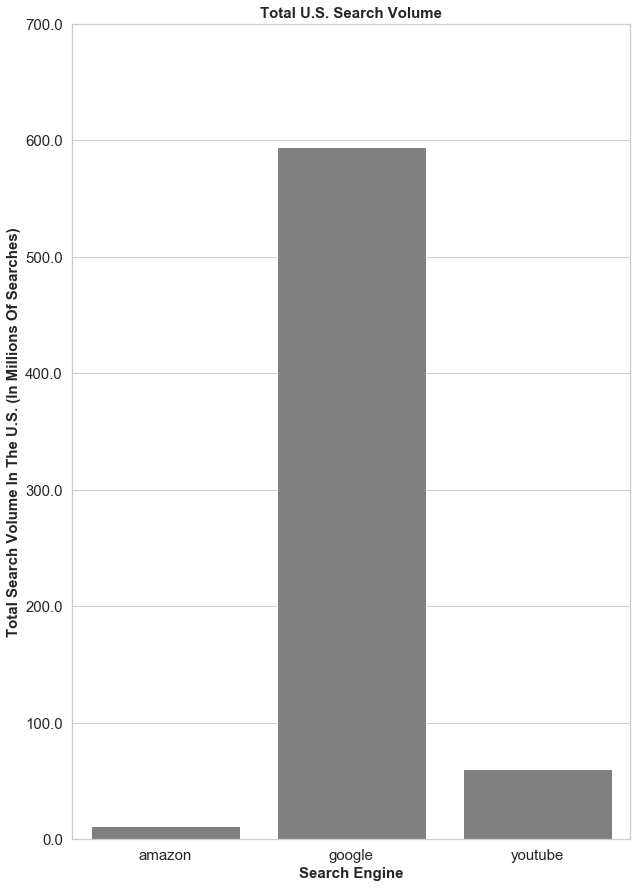

```python
#barplot of total search volume across all 3 major search engines

sns.set(style="whitegrid", color_codes=True, font_scale=1.7)
fig, ax = plt.subplots()
fig.set_size_inches(10,15)
ax = sns.barplot(x="engine", y="sum", ci=None, color='grey', data=total_volume_usa)
plt.xlabel('Search Engine', fontsize=15, weight = 'bold')
plt.ylabel('Total Search Volume In The U.S. (In Millions Of Searches)', fontsize=15, weight = 'bold')
plt.title('Total U.S. Search Volume', fontsize=15, weight = 'bold')
ax.set_xticklabels(ax.get_xticklabels(), fontsize=15, rotation=0)
ax.set_yticklabels(ax.get_yticklabels(), fontsize=15, rotation=0)
plt.yticks(ax.get_yticks(), ax.get_yticks()/1000000)
plt.show()

# plt.savefig('Total U.S. Search Volume.pdf', dpi=300)
```

#### Initial Observations

Between the 3 search engines, **Google clearly has the vastest total U.S. search volume compared to YouTube and Amazon.** Google's U.S. search volume (about 600 million) in the Wordtracker database is approximately 10x larger than YouTube (about 60 million), and 50x larger than Amazon (about 12 million). Based on this, we might guess that Google will have the largest search volumes for each "athleisure" related keyword, just because of its sheer volume.

#### Plot total volume for ATHLEISURE KEYWORDS ONLY across all 3 search engines

```python
total_volume_keywords_usa = pd.DataFrame(df.groupby('engine').volume.sum())
total_volume_keywords_usa = total_volume_keywords_usa.reset_index()
```

```python
total_volume_keywords_usa.sort_values('engine', ascending=True)
```

|  | engine | volume |
| --- | --- | --- |
| 0 | amazon | 3112204 |
| 1 | google | 66634 |
| 2 | youtube | 3995449 |

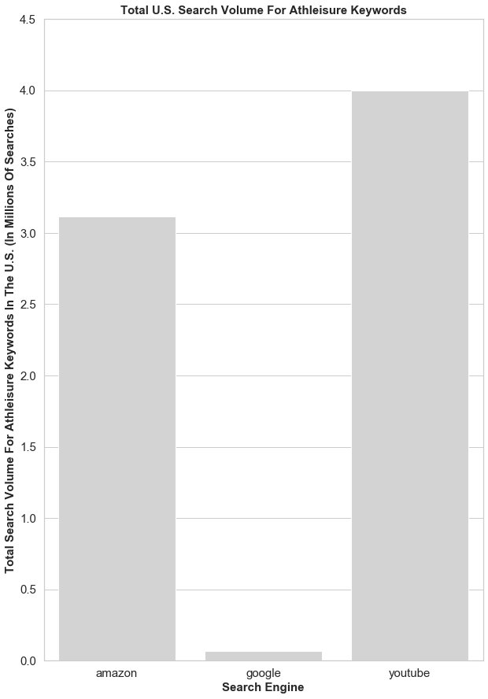

```python
#barplot of total search volume for our 77 keywords only across all 3 major search engines

sns.set(style="whitegrid", color_codes=True, font_scale=1.7)
fig, ax = plt.subplots()
fig.set_size_inches(10,15)
ax = sns.barplot(x="engine", y="volume", ci=None, color='lightgrey', data=total_volume_keywords_usa)
plt.xlabel('Search Engine', fontsize=15, weight = 'bold')
plt.ylabel('Total Search Volume For Athleisure Keywords In The U.S. (In Millions Of Searches)', fontsize=15, weight = 'bold')
plt.title('Total U.S. Search Volume For Athleisure Keywords', fontsize=15, weight = 'bold')
ax.set_xticklabels(ax.get_xticklabels(), fontsize=15, rotation=0)
ax.set_yticklabels(ax.get_yticklabels(), fontsize=15, rotation=0)
plt.yticks(ax.get_yticks(), ax.get_yticks()/1000000)
plt.show()

# plt.savefig('Total U.S. Search Volume For Athleisure Keywords.pdf', dpi=300)
```

#### Initial Observations

Between the 3 search engines, **even though Google has the largest search volume compared to YouTube and Amazon, Google has the SMALLEST search volume for "athleisure" related keywords, by a significant margin.** For athleisure related keywords, Google only has a meager 67,000 searches in the U.S., whereas Amazon has over 3 million searches, and YouTube has nearly 4 million searches! Based on this finding, it seems that overall search engine volume does not always influence the volume of searching a particular topic. People may be searching more for athleisure related keywords on Amazon and Youtube, much more than on Google, even though Google gets more search volume in general.

```python
athleisure_search_ratio = list(total_volume_keywords_usa['volume'] / total_volume_usa['sum'])
# for some reason 2 "NaN" values showed up - need to .pop() those values away.
athleisure_search_ratio.pop()
athleisure_search_ratio.pop()
athleisure_search_ratio
```

```
[0.2670568140717359, 0.00523733322288535, 0.05143440185265413]
```

```python
search_ratio_df = pd.merge(total_volume_keywords_usa, total_volume_usa)
search_ratio_df
```

|  | engine | volume | sum | country_code |
| --- | --- | --- | --- | --- |
| 0 | amazon | 3112204 | 11653715 | US |
| 1 | google | 66634 | 594234483 | US |
| 2 | youtube | 3995449 | 60508218 | US |

```python
search_ratio_df['ratio'] = athleisure_search_ratio
search_ratio_df
```

|  | engine | volume | sum | country_code | ratio |
| --- | --- | --- | --- | --- | --- |
| 0 | amazon | 3112204 | 11653715 | US | 0.267057 |
| 1 | google | 66634 | 594234483 | US | 0.005237 |
| 2 | youtube | 3995449 | 60508218 | US | 0.051434 |

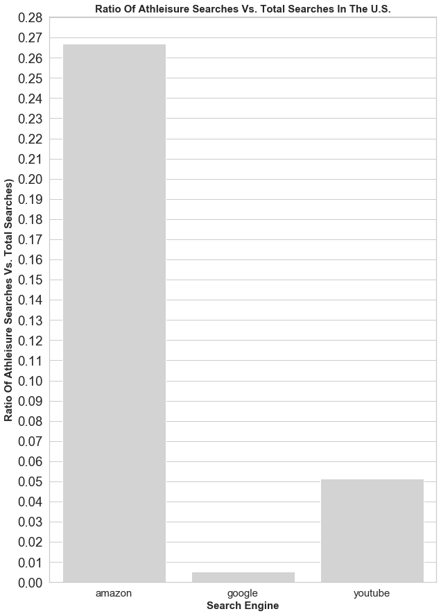

```python
#barplot of total search volume for our 77 keywords only across all 3 major search engines

sns.set(style="whitegrid", color_codes=True, font_scale=1.7)
fig, ax = plt.subplots()
fig.set_size_inches(10,15)
ax = sns.barplot(x="engine", y="ratio", ci=None, color='lightgrey', data=search_ratio_df)
plt.xlabel('Search Engine', fontsize=15, weight = 'bold')
plt.ylabel('Ratio Of Athleisure Searches Vs. Total Searches)', fontsize=15, weight = 'bold')
plt.title('Ratio Of Athleisure Searches Vs. Total Searches In The U.S.', fontsize=15, weight = 'bold')
ax.set_xticklabels(ax.get_xticklabels(), fontsize=15, rotation=0)
ax.yaxis.set_major_locator(ticker.MultipleLocator(.01))
ax.yaxis.set_major_formatter(ticker.ScalarFormatter())
plt.show()

# plt.savefig('Ratio Of Athleisure Searches Vs. Total Searches In The U.S.pdf', dpi=300)
```